# Упражнение 8

Никишов Дмитрий

12 05 2021

Построить две модели для прогноза на основе дерева решений:

1. для непрерывной зависимой переменной;
2. для категориальной зависимой переменной.

Данные и переменные указаны в таблице с вариантами. Ядро генератора случайных чисел – номер варианта.

Для каждой модели:

1. Указать настроечные параметры метода из своего варианта (например: количество узлов, количество предикторов, скорость обучения).
2. Подогнать модель на обучающей выборке (50% наблюдений). Рассчитать MSE на тестовой выборке.
3. Перестроить модель с помощью метода, указанного в варианте.
4. Сделать прогноз по модели с подобранными в п.3 параметрами на тестовой выборке, оценить его точность и построить график «прогноз-реализация».

# Вариант 21(1)

# Данные:

- Boston {MASS}
- Непрерывный Y: medv
- Метод подгонки моделей: дерево с обрезкой ветвей

```r
# Название столбцов переменных
names(Boston)
```

```
##  [1] "crim"    "zn"      "indus"   "chas"    "nox"     "rm"      "age"
##  [8] "dis"     "rad"     "tax"     "ptratio" "black"   "lstat"   "medv"
```

```r
# Размерность данных
dim(Boston)
```

```
## [1] 506  14
```

# Модель 1 (для непрерывной зависимой переменной medv)

```r
# ?Boston
head(Boston)
```

```
##      crim zn indus chas   nox    rm  age    dis rad tax ptratio  black lstat
## 1 0.00632 18  2.31    0 0.538 6.575 65.2 4.0900   1 296    15.3 396.90  4.98
## 2 0.02731  0  7.07    0 0.469 6.421 78.9 4.9671   2 242    17.8 396.90  9.14
## 3 0.02729  0  7.07    0 0.469 7.185 61.1 4.9671   2 242    17.8 392.83  4.03
## 4 0.03237  0  2.18    0 0.458 6.998 45.8 6.0622   3 222    18.7 394.63  2.94
## 5 0.06905  0  2.18    0 0.458 7.147 54.2 6.0622   3 222    18.7 396.90  5.33
## 6 0.02985  0  2.18    0 0.458 6.430 58.7 6.0622   3 222    18.7 394.12  5.21
##   medv
## 1 24.0
## 2 21.6
## 3 34.7
## 4 33.4
## 5 36.2
## 6 28.7
```

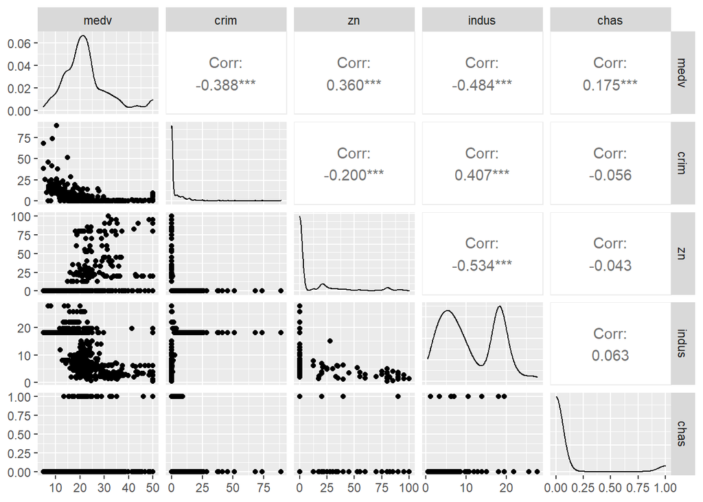

```r
# Матричные графики разброса переменных
p <- ggpairs(Boston[, c(14, 1:4)])
suppressMessages(print(p))
```

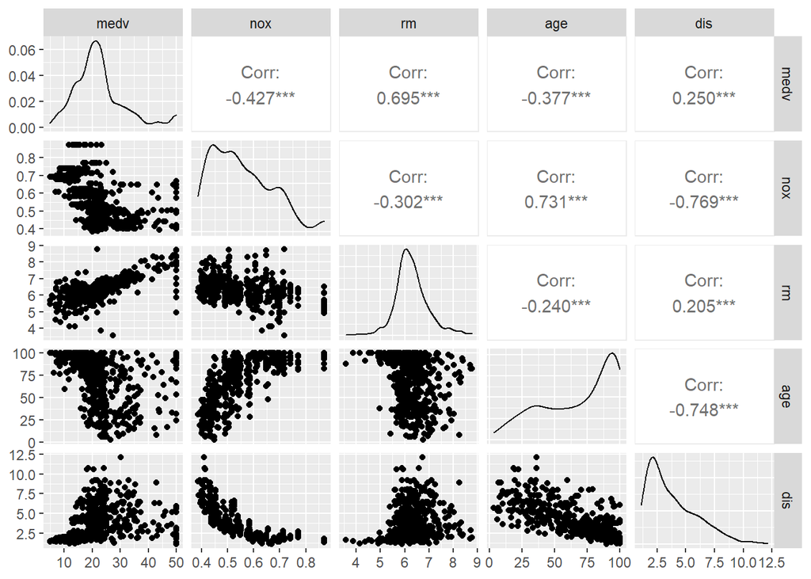

```r
p <- ggpairs(Boston[, c(14, 5:8)])
suppressMessages(print(p))
```

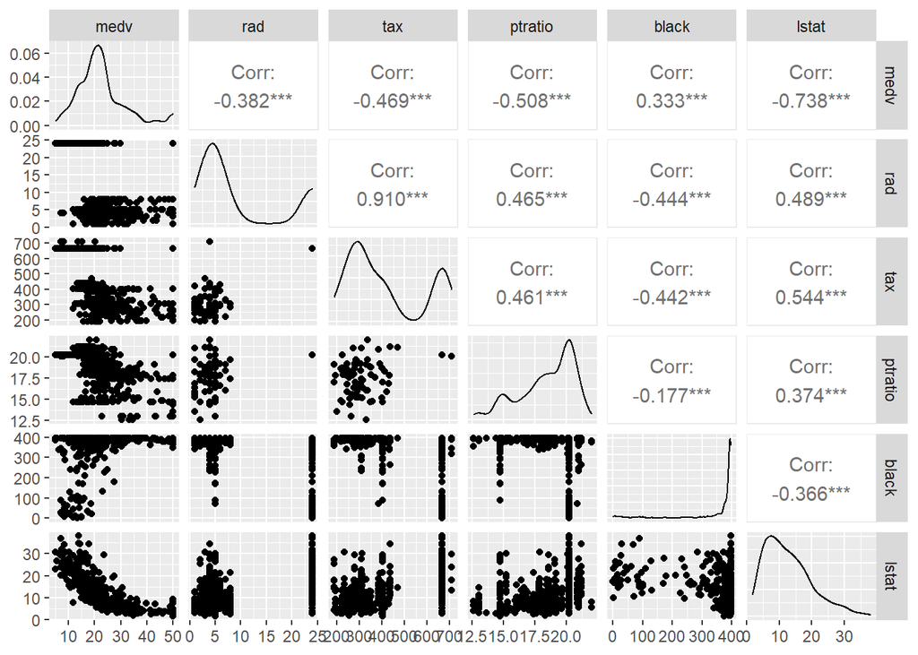

```r
p <- ggpairs(Boston[, c(14, 9:13)])
suppressMessages(print(p))
```

```r
# Обучающая выборка
set.seed(my.seed)
# Обучающая выборка - 50%
train <- sample(1:nrow(Boston), nrow(Boston)/2)
```

Построим дерево регрессии для зависимой переменной medv

```r
# Обучаем модель
tree.boston <- tree(medv ~ ., Boston, subset = train)
summary(tree.boston)
```

```
##
## Regression tree:
## tree(formula = medv ~ ., data = Boston, subset = train)
## Variables actually used in tree construction:
## [1] "rm"    "lstat" "crim"  "age"
## Number of terminal nodes:  7
## Residual mean deviance:  10.38 = 2555 / 246
## Distribution of residuals:
##     Min.  1st Qu.   Median     Mean  3rd Qu.     Max.
## -10.1800  -1.7770  -0.1775   0.0000   1.9230  16.5800
```

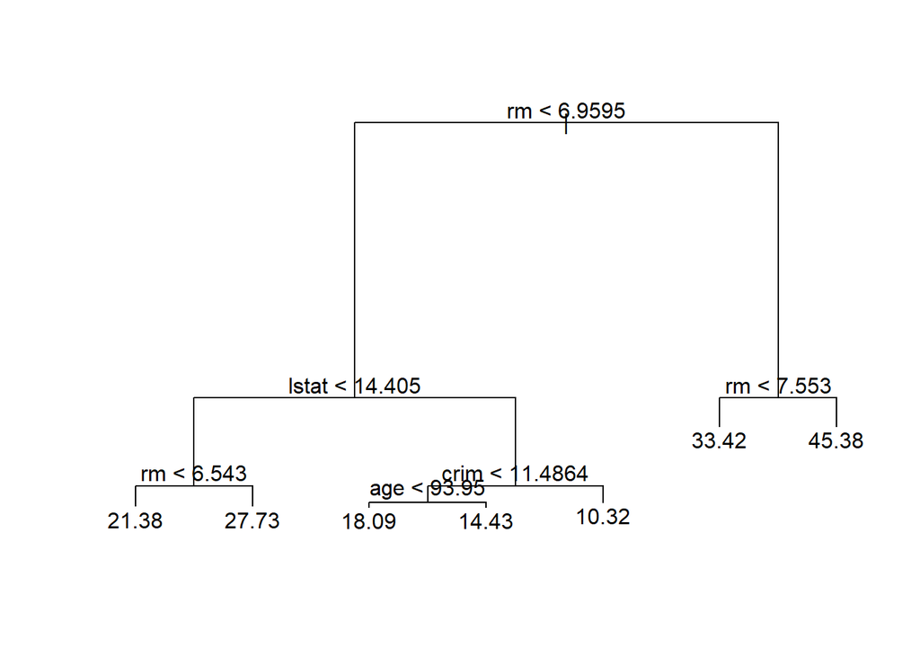

```r
# Визуализация
plot(tree.boston)
text(tree.boston, pretty = 0)
```

```r
tree.boston                    # Посмотреть всё дерево в консоли
```

```
## node), split, n, deviance, yval
##       * denotes terminal node
##
##  1) root 253 19450.0 21.79
##    2) rm < 6.9595 222  6794.0 19.35
##      4) lstat < 14.405 135  1816.0 22.51
##        8) rm < 6.543 111   763.1 21.38 *
##        9) rm > 6.543 24   256.5 27.73 *
##      5) lstat > 14.405 87  1554.0 14.46
##       10) crim < 11.4864 61   613.8 16.23
##         20) age < 93.95 30   245.7 18.09 *
##         21) age > 93.95 31   164.1 14.43 *
##       11) crim > 11.4864 26   302.7 10.32 *
##    3) rm > 6.9595 31  1929.0 39.21
##      6) rm < 7.553 16   505.5 33.42 *
##      7) rm > 7.553 15   317.0 45.38 *
```

```r
# Прогноз по модели
yhat <- predict(tree.boston, newdata = Boston[-train, ])
boston.test <- Boston[-train, "medv"]

# MSE на тестовой выборке
mse.test <- mean((yhat - boston.test)^2)
names(mse.test)[length(mse.test)] <- 'Boston.regr.tree.all'
mse.test
```

```
## Boston.regr.tree.all
##             35.28688
```

```r
# Точность прогноза на тестовой выборке
acc.test <- sum(abs(yhat-boston.test))/sum(boston.test)
names(acc.test)[length(acc.test)] <- 'Boston.regr.tree.all'
acc.test
```

```
## Boston.regr.tree.all
##            0.1586236
```

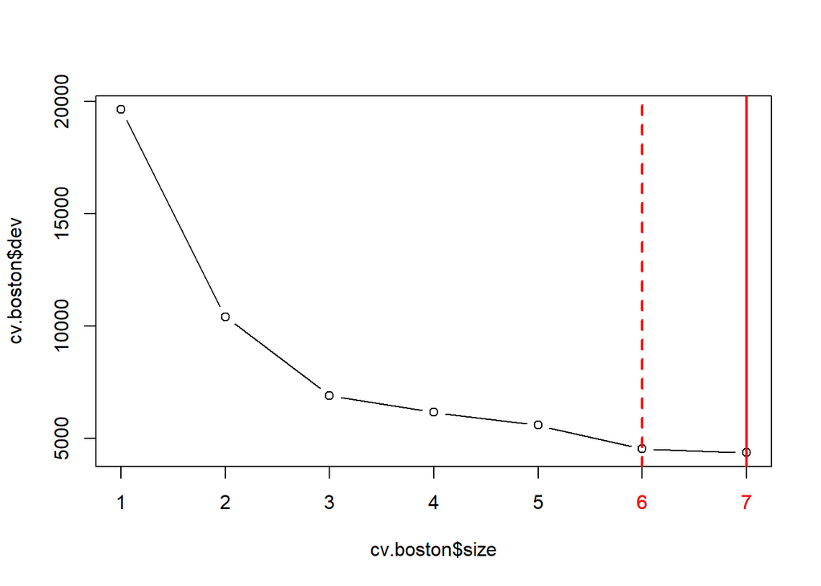

```r
# обрезка дерева
cv.boston <- cv.tree(tree.boston)

# размер дерева с минимальной ошибкой
plot(cv.boston$size, cv.boston$dev, type = 'b')
opt.size <- cv.boston$size[cv.boston$dev == min(cv.boston$dev)]
abline(v = opt.size, col = 'red', 'lwd' = 2)     # соотв. вертикальная прямая
mtext(opt.size, at = opt.size, side = 1, col = 'red', line = 1)

abline(v = 6, col = 'red', 'lwd' = 2, lty=2)     # соотв. вертикальная прямая
mtext(6, at = 6, side = 1, col = 'red', line = 1)
```

# Модель 2 (для категориальной зависимой переменной high.medv)

1, если medv >= 25 0, если medv < 25

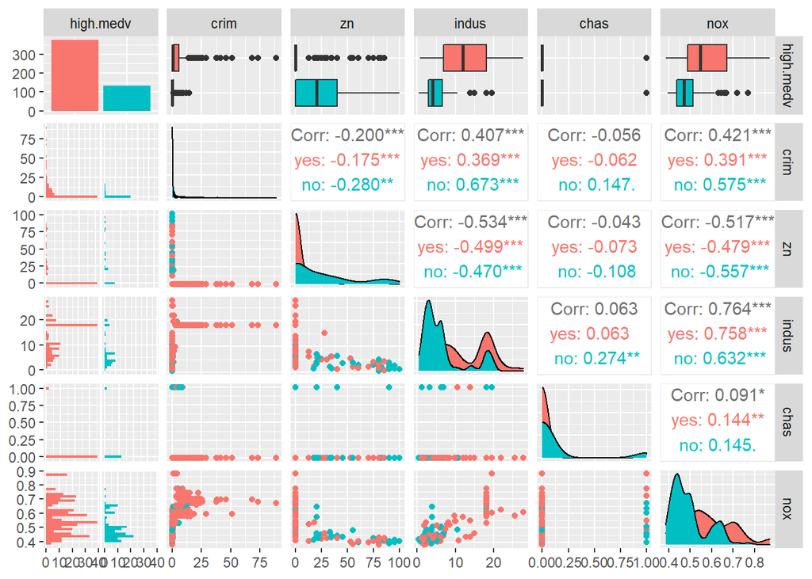

```r
# новая переменная
high.medv <- ifelse(Boston$medv >= 25, 1, 0)
high.medv <- factor(high.medv, labels = c('yes', 'no'))
Boston$high.medv <- high.medv
# матричные графики разброса переменных
p <- ggpairs(Boston[, c(15, 1:5)], aes(color = high.medv))
suppressMessages(print(p))
```

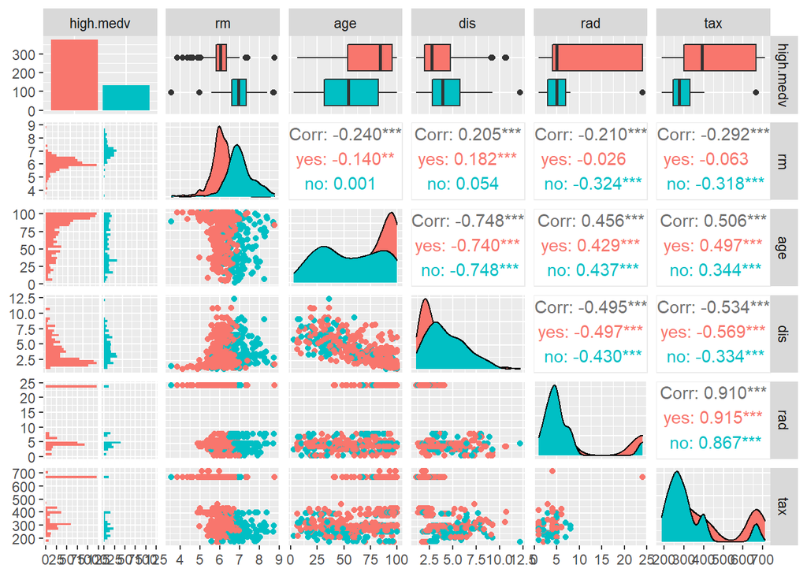

```r
p <- ggpairs(Boston[, c(15, 6:10)], aes(color = high.medv))
suppressMessages(print(p))
```

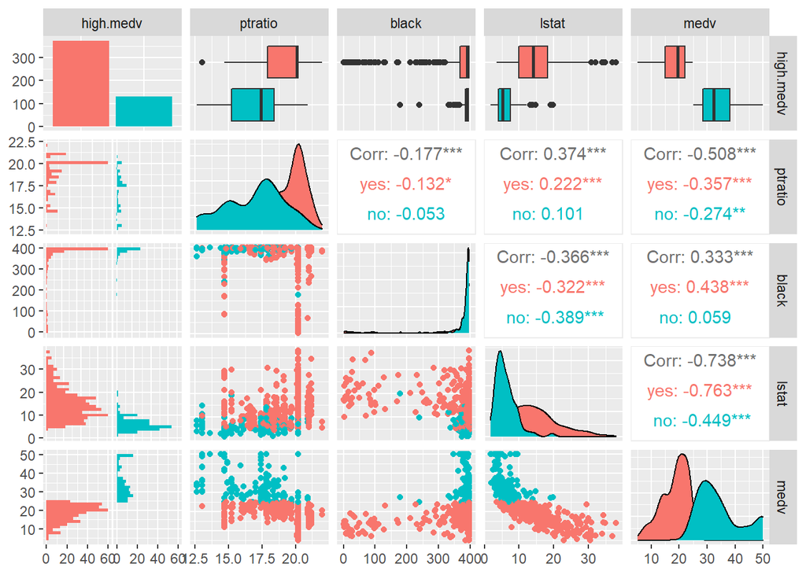

```r
p <- ggpairs(Boston[, c(15, 11:14)], aes(color = high.medv))
suppressMessages(print(p))
```

```r
# модель бинарного  дерева без переменных medv и name
tree.boston <- tree(high.medv ~ .-medv, Boston)
summary(tree.boston)
```

```
##
## Classification tree:
## tree(formula = high.medv ~ . - medv, data = Boston)
## Variables actually used in tree construction:
## [1] "rm"    "lstat" "crim"  "tax"   "age"   "indus" "nox"
## Number of terminal nodes:  16
## Residual mean deviance:  0.1975 = 96.77 / 490
## Misclassification error rate: 0.03557 = 18 / 506
```

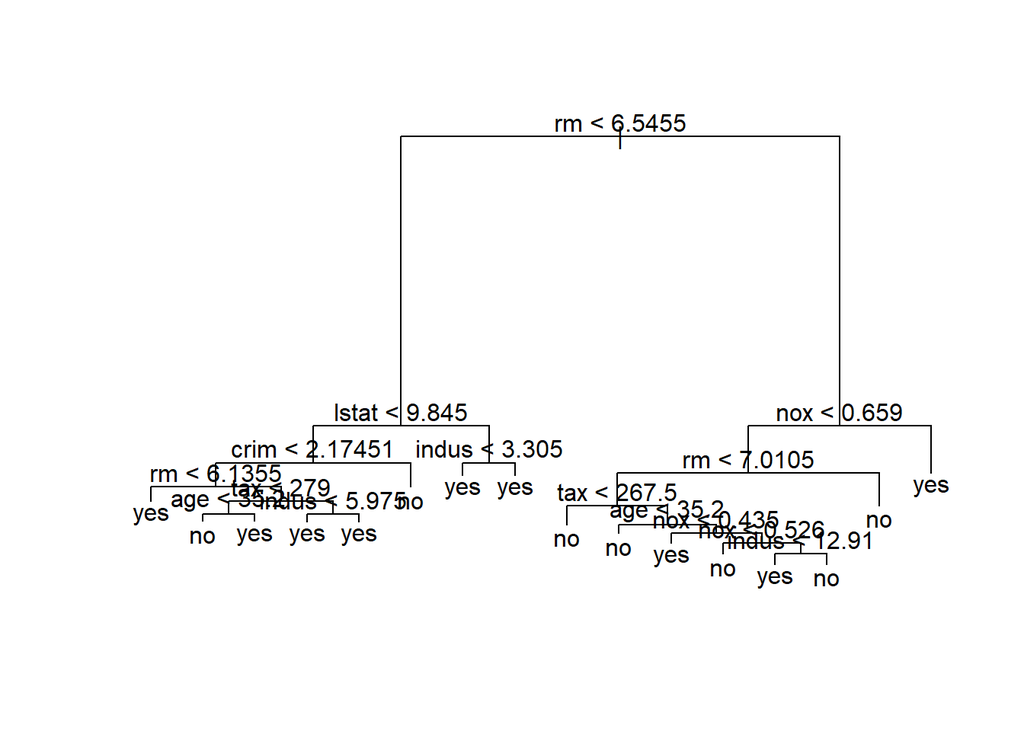

```r
# график результата:
# ветви
plot(tree.boston)
# добавим подписи
text(tree.boston, pretty = 0)
```

```r
# посмотреть всё дерево в консоли
tree.boston
```

```
## node), split, n, deviance, yval, (yprob)
##       * denotes terminal node
##
##   1) root 506 580.900 yes ( 0.739130 0.260870 )
##     2) rm < 6.5455 362 165.900 yes ( 0.939227 0.060773 )
##       4) lstat < 9.845 93  91.390 yes ( 0.806452 0.193548 )
##         8) crim < 2.17451 87  69.810 yes ( 0.862069 0.137931 )
##          16) rm < 6.1355 33   0.000 yes ( 1.000000 0.000000 ) *
##          17) rm > 6.1355 54  57.210 yes ( 0.777778 0.222222 )
##            34) tax < 279 18  24.950 no ( 0.500000 0.500000 )
##              68) age < 35.2 7   5.742 no ( 0.142857 0.857143 ) *
##              69) age > 35.2 11  12.890 yes ( 0.727273 0.272727 ) *
##            35) tax > 279 36  20.650 yes ( 0.916667 0.083333 )
##              70) indus < 5.975 23   0.000 yes ( 1.000000 0.000000 ) *
##              71) indus > 5.975 13  14.050 yes ( 0.769231 0.230769 ) *
##         9) crim > 2.17451 6   0.000 no ( 0.000000 1.000000 ) *
##       5) lstat > 9.845 269  41.610 yes ( 0.985130 0.014870 )
##        10) indus < 3.305 5   6.730 yes ( 0.600000 0.400000 ) *
##        11) indus > 3.305 264  23.520 yes ( 0.992424 0.007576 ) *
##     3) rm > 6.5455 144 157.400 no ( 0.236111 0.763889 )
##       6) nox < 0.659 131 115.300 no ( 0.160305 0.839695 )
##        12) rm < 7.0105 71  86.230 no ( 0.295775 0.704225 )
##          24) tax < 267.5 20   0.000 no ( 0.000000 1.000000 ) *
##          25) tax > 267.5 51  69.100 no ( 0.411765 0.588235 )
##            50) age < 35.2 15  11.780 no ( 0.133333 0.866667 ) *
##            51) age > 35.2 36  49.800 yes ( 0.527778 0.472222 )
##             102) nox < 0.435 6   0.000 yes ( 1.000000 0.000000 ) *
##             103) nox > 0.435 30  41.050 no ( 0.433333 0.566667 )
##               206) nox < 0.526 14  11.480 no ( 0.142857 0.857143 ) *
##               207) nox > 0.526 16  19.870 yes ( 0.687500 0.312500 )
##                 414) indus < 12.91 8   0.000 yes ( 1.000000 0.000000 ) *
##                 415) indus > 12.91 8  10.590 no ( 0.375000 0.625000 ) *
##        13) rm > 7.0105 60   0.000 no ( 0.000000 1.000000 ) *
##       7) nox > 0.659 13   0.000 yes ( 1.000000 0.000000 ) *
```

Теперь построим дерево на обучающей выборке и оценим ошибку на тестовой.

```r
# ядро генератора случайных чисел по номеру варианта

set.seed(my.seed)

# обучающая выборка 50%
train <- sample(1:nrow(Boston), 200)

# тестовая выборка
boston.test <- Boston[-train,]
high.medv.test <- high.medv[-train]

# строим дерево на обучающей выборке
tree.boston <- tree(high.medv ~ .-medv, Boston, subset = train)
summary(tree.boston)
```

```
##
## Classification tree:
## tree(formula = high.medv ~ . - medv, data = Boston, subset = train)
## Variables actually used in tree construction:
## [1] "rm"    "lstat" "nox"   "age"   "crim"  "tax"
## Number of terminal nodes:  9
## Residual mean deviance:  0.1408 = 26.89 / 191
## Misclassification error rate: 0.035 = 7 / 200
```

```r
# делаем прогноз
tree.pred <- predict(tree.boston, boston.test, type = "class")

# матрица неточностей
tbl <- table(tree.pred, high.medv.test)
tbl
```

```
##          high.medv.test
## tree.pred yes  no
##       yes 205  22
##       no   16  63
```

```r
# ACC на тестовой
acc.test <- sum(diag(tbl))/sum(tbl)
names(acc.test)[length(acc.test)] <- 'Boston.class.tree.all'
acc.test
```

```
## Boston.class.tree.all
##              0.875817
```

Теперь обрезаем дерево, используя в качестве критерия частоту ошибок классификации. Функция cv.tree() проводит кросс-валидацию для выбора лучшего дерева, аргумент prune.misclass означает, что мы минимизируем ошибку классификации.

```r
set.seed(my.seed)
cv.boston <- cv.tree(tree.boston, FUN = prune.misclass)
# имена элементов полученного объекта
names(cv.boston)
```

```
## [1] "size"   "dev"    "k"      "method"
```

```r
# сам объект
cv.boston
```

```
## $size
## [1] 9 8 5 3 2 1
##
## $dev
## [1] 18 17 17 14 18 48
##
## $k
## [1]       -Inf  0.0000000  0.3333333  1.0000000  6.0000000 31.0000000
##
## $method
## [1] "misclass"
##
## attr(,"class")
## [1] "prune"         "tree.sequence"
```

Графики изменения параметров метода по ходу обрезки дерева

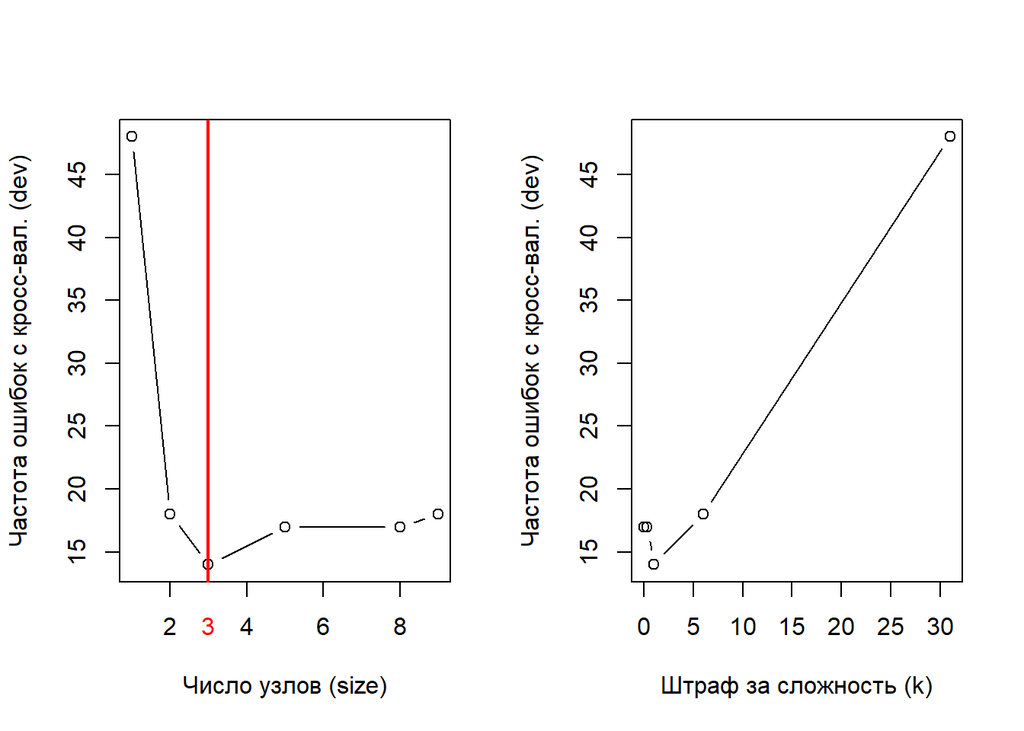

```r
# 1. ошибка с кросс-валидацией в зависимости от числа узлов
par(mfrow = c(1, 2))
plot(cv.boston$size, cv.boston$dev, type = "b",
     ylab = 'Частота ошибок с кросс-вал. (dev)',
     xlab = 'Число узлов (size)')
# размер дерева с минимальной ошибкой
opt.size <- cv.boston$size[cv.boston$dev == min(cv.boston$dev)]
abline(v = opt.size, col = 'red', 'lwd' = 2)     # соотв. вертикальная прямая
mtext(opt.size, at = opt.size, side = 1, col = 'red', line = 1)

# 2. ошибка с кросс-валидацией в зависимости от штрафа на сложность
plot(cv.boston$k, cv.boston$dev, type = "b",
     ylab = 'Частота ошибок с кросс-вал. (dev)',
     xlab = 'Штраф за сложность (k)')
```

Как видно на графике слева, минимум частоты ошибок достигается при числе узлов 3.

Оценим точность дерева с 3 узлами.

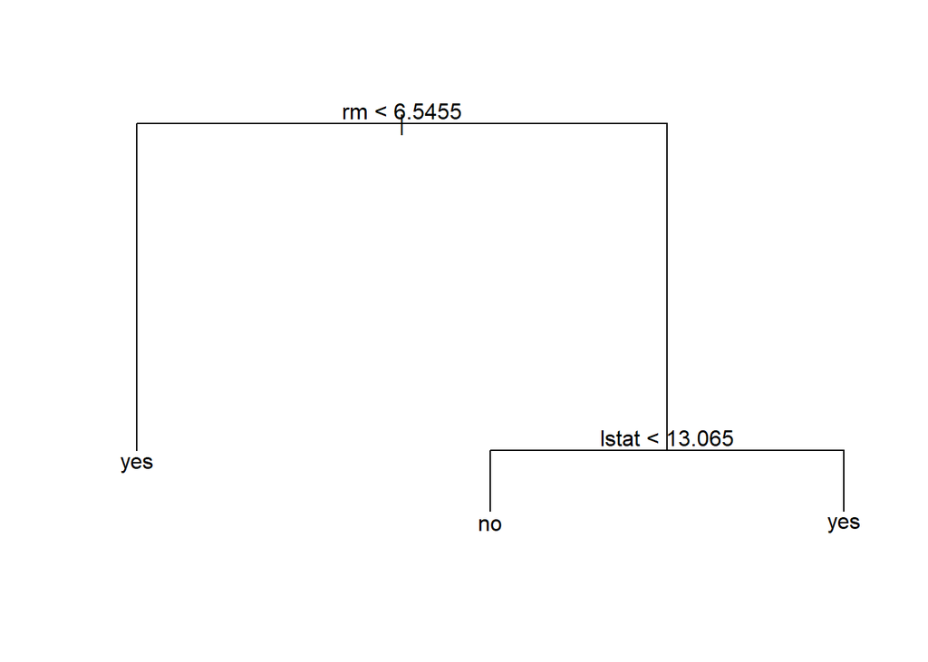

```r
# дерево с 3 узлами
prune.boston <- prune.misclass(tree.boston, best = 3)

# визуализация
plot(prune.boston)
text(prune.boston, pretty = 0)
```

```r
# прогноз на тестовую выборку
tree.pred <- predict(prune.boston, boston.test, type = "class")

# матрица неточностей
tbl <- table(tree.pred, high.medv.test)
tbl
```

```
##          high.medv.test
## tree.pred yes  no
##       yes 206  19
##       no   15  66
```

```r
# ACC на тестовой
acc.test <- c(acc.test, sum(diag(tbl))/sum(tbl))
names(acc.test)[length(acc.test)] <- 'Boston.class.tree.3'
acc.test
```

```
## Boston.class.tree.all   Boston.class.tree.3
##             0.8758170             0.8888889
```

Точность этой модели почти не изменилась и составляет 0,89.

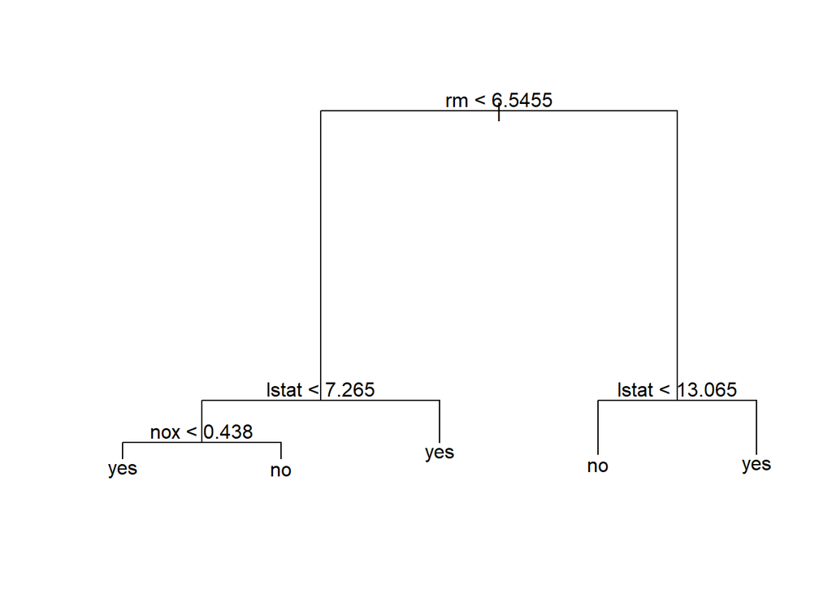

```r
# дерево с 4 узлами
prune.boston <- prune.misclass(tree.boston, best = 4)

# визуализация
plot(prune.boston)
text(prune.boston, pretty = 0)
```

```r
# прогноз на тестовую выборку
tree.pred <- predict(prune.boston, boston.test, type = "class")

# матрица неточностей
tbl <- table(tree.pred, high.medv.test)
tbl
```

```
##          high.medv.test
## tree.pred yes  no
##       yes 196  13
##       no   25  72
```

```r
# ACC на тестовой
acc.test <- c(acc.test, sum(diag(tbl))/sum(tbl))
names(acc.test)[length(acc.test)] <- 'Carseats.class.tree.4'
acc.test
```

```
## Boston.class.tree.all   Boston.class.tree.3 Carseats.class.tree.4
##             0.8758170             0.8888889             0.8758170
```